# Multivariate Data Analysis Assignment #4

2018170865 산업경영공학부 박재현

2021. 5. 15.

```r
suppressMessages({
    library(tree)
    library(party)
    library(ROCR)
})
```

## [Q1] 본인이 생각하기에 “예측정확도”도 중요하지만 “예측 결과물에 대한 해석”이 매우 중요할 것으로 생각되는 분류문제를 다 루고 있는 데이터셋을 1개 선정하고 선정 이유를 설명하시오. 데이터셋 탐색은 아래에서 제시된 Data Repository를 포함하여 여러 Repository를 검색해서 결정하시오. 보고서에는 데이터를 다운로드할 수 있는 링크를 반드시 제공하시오.

### Wine 데이터셋

데이터 : Red Wine Quality 데이터셋 출처 : https://www.kaggle.com/uciml/red-wine-quality-cortez-et-al-2009

변수

| 1 | fixed acidity |
| --- | --- |
| 2 | volatile acidity |
| 3 | citric acid |
| 4 | residual sugar |
| 5 | chlorides |
| 6 | free sulfur dioxide |
| 7 | total sulfur dioxide |
| 8 | density |
| 9 | pH |
| 10 | sulphates |
| 11 | alcohol |
| 12 | quality (score between 0 and 10) |

와인의 품질 예측에 사용되는 데이터셋이다. 품질(Y)은 1~10점 척도로 평가된다. 6.5점 이상은 좋은 품질의 와인, 6.5점 이하는 나쁜 품질의 와인으로 분류한다. 예측에 정확하다는 가정하에, 와인 판매점에서 단순히 품질 척도만 가지고 판매를 하는 것은 다소 바람직하지 않다. 같은 점수를 받은 와인들의 산도, 당도, 염도, 도수 같은 특징이 동일하지 않기 때문이다. 고객에게 구매를 권하기 위해서는 품질 뿐만 아니라 품질에 영향을 끼친 feature에 대한 해석이 중요하게 작용할 것으로 생각된다.

> (가이드라인) 두 가지 데이터셋에 대해서 학습:검증:테스트 용도 로 적절히 분배 하시오(예: 60:20:20). 본인이 분배한 비율에 대해서 간략히 그 근거를 설명 하시오. 분류 성능을 평가/비교할 때는 TPR, TNR, Precision, Accuracy, BCR, F1-Measure, AUROC를 복합적으로 고려하여 의견을 서술하시오.

데이터셋을 7:0:3의 비율로 분배해서 각각 학습, 테스트를 진행할 것이다. 관례적으로 valid set은 생략을 하고 train과 test 데이터셋으로 학습을 진행하는 경우도 존재하고, 게다가 데이터의 관측치가 1599개 밖에 되지 않기때문에 3개의 데이터셋으로 나누면 각 분배한 셋의 관측치가 작아지기 때문에 bias가 생길 가능성이 높아진다. 따라서 검증 데이터셋은 이번 과제에서 사용하지 않을 것이다. 학습 데이터셋과 테스트 데이터셋의 비율은 관례적으로 많이 사용하는 7:3을 사용하였다(rule of thumb).  
반면,두번째 Q3에서는 validation set 사용이 조건에 들어가 있으므로 6:2:2의 비율을 사용해서 데이터셋을 분배하였다.

## Titanic 데이터셋

타이타닉 데이터셋은 원래 train과 test가 분리되어 제공된다. 앞에서는 train데이터를 train과 test로 분리하여 사용하고, 두번째 Q3에서는 train을 train과 valid로 분리하고, test는 기존의 test 데이터를 사용할 것이다.

# (두 가지 데이터셋에 대해서 아래 질문들을 각각 수행하시오)

## [Q2] 실습 시간에 사용한 “tree” package를 사용하여 Classification Tree를 학습한 결과물을 Plotting하고 이에 대한 해석을 수행하시오. 또한 해당 Tree를 pruning을 수행하지 않은 상태에서 Test dataset에 대한 분류 성능을 평가하시오.

### Wine 데이터

#### 해석

도수가 10.45도 보다 낮으면 트리의 왼쪽으로 가게되고, 해당 제품은 이후 split에 상관없이 나쁜 품질에 해당하게 된다.루트 노드의 오른쪽으로 가게 되면 다시 알코올의 도수를 기준(11.55)으로 분리 되고, sulphate(황산염), volatile acidity(휘발성 산), total sulfur dioxide(총 이산화항) 등의 변수로 노드가 계속 분리된다.  
한가지 예를 들면, 어떤 와인이 도수가 10.45도 보다는 크고 11.55도보다는 작으며, volatile acidity가 0.375보다 작으며, pH가 3.255보다 작은 와인은 좋은 와인으로 분류된다.

#### 분류 성능 평가

정확도와 True Negative는 높지만 True Positive, Precision, BCR, F1, AUROC의 값은 다소 낮은 값이 나타난다. 정확도만 평가했을 때는 좋은 성능을 가진 모델이라고 할 수 있지만 종합적으로 고려한다면 성능이 좋은 모델이라고 하기 어렵다. TN가 높기에 나쁜 와인을 골라내는데 사용할 수 있는 분류기라고 생각할 수 있다. 이외의 목적으로 사용할 경우 좋은 분류를 해주지 못한다.

|  | TPR | PRE | TNR | ACC | BCR | F1 | AUROC |
| --- | --- | --- | --- | --- | --- | --- | --- |
| 성능 | 0.46 | 0.67 | 0.96 | 0.90 | 0.67 | 0.55 | 0.71 |

```r
# Performance Evaluation Function -----------------------------------------
perf_eval <- function(cm){

  # True positive rate: TPR (Recall)
  TPR <- cm[2,2]/sum(cm[2,])
  # Precision
  PRE <- cm[2,2]/sum(cm[,2])
  # True negative rate: TNR
  TNR <- cm[1,1]/sum(cm[1,])
  # Simple Accuracy
  ACC <- (cm[1,1]+cm[2,2])/sum(cm)
  # Balanced Correction Rate
  BCR <- sqrt(TPR*TNR)
  # F1-Measure
  F1 <- 2*TPR*PRE/(TPR+PRE)

  return(c(TPR, PRE, TNR, ACC, BCR, F1))
}

# Performance table
Perf_Table <- matrix(0, nrow = 2, ncol = 6)
rownames(Perf_Table) <- c("Post-Pruning", "Pre-Pruning")
colnames(Perf_Table) <- c("TPR", "Precision", "TNR", "Accuracy", "BCR", "F1-Measure")
Perf_Table
```

```
             TPR Precision TNR Accuracy BCR F1-Measure
Post-Pruning   0         0   0        0   0          0
Pre-Pruning    0         0   0        0   0          0
```

```r
set.seed(12345)

wine <- read.csv("winequality-red.csv")
str(wine)
```

```
'data.frame':   1599 obs. of  12 variables:
 $ fixed.acidity       : num  7.4 7.8 7.8 11.2 7.4 7.4 7.9 7.3 7.8 7.5 ...
 $ volatile.acidity    : num  0.7 0.88 0.76 0.28 0.7 0.66 0.6 0.65 0.58 0.5 ...
 $ citric.acid         : num  0 0 0.04 0.56 0 0 0.06 0 0.02 0.36 ...
 $ residual.sugar      : num  1.9 2.6 2.3 1.9 1.9 1.8 1.6 1.2 2 6.1 ...
 $ chlorides           : num  0.076 0.098 0.092 0.075 0.076 0.075 0.069 0.065 0.073 0.071 ...
 $ free.sulfur.dioxide : num  11 25 15 17 11 13 15 15 9 17 ...
 $ total.sulfur.dioxide: num  34 67 54 60 34 40 59 21 18 102 ...
 $ density             : num  0.998 0.997 0.997 0.998 0.998 ...
 $ pH                  : num  3.51 3.2 3.26 3.16 3.51 3.51 3.3 3.39 3.36 3.35 ...
 $ sulphates           : num  0.56 0.68 0.65 0.58 0.56 0.56 0.46 0.47 0.57 0.8 ...
 $ alcohol             : num  9.4 9.8 9.8 9.8 9.4 9.4 9.4 10 9.5 10.5 ...
 $ quality             : int  5 5 5 6 5 5 5 7 7 5 ...
```

```r
wine$quality <- ifelse(wine$quality >= 6.5, 1, 0)
wine$quality <- as.factor(wine$quality)

ratio <- 0.7
indexes <- sample(2, nrow(wine), replace=TRUE, prob=c(ratio, 1-ratio))
wine_train <- wine[indexes==1,]
wine_test <- wine[indexes==2,]

CART_post <- tree(quality ~ .,data = wine_train)
summary(CART_post)
```

```
Classification tree:
tree(formula = quality ~ ., data = wine_train)
Variables actually used in tree construction:
[1] "alcohol"              "fixed.acidity"        "sulphates"            "volatile.acidity"
[5] "pH"                   "residual.sugar"       "total.sulfur.dioxide" "free.sulfur.dioxide"
Number of terminal nodes:  17
Residual mean deviance:  0.3993 = 425.3 / 1065
Misclassification error rate: 0.08041 = 87 / 1082
```

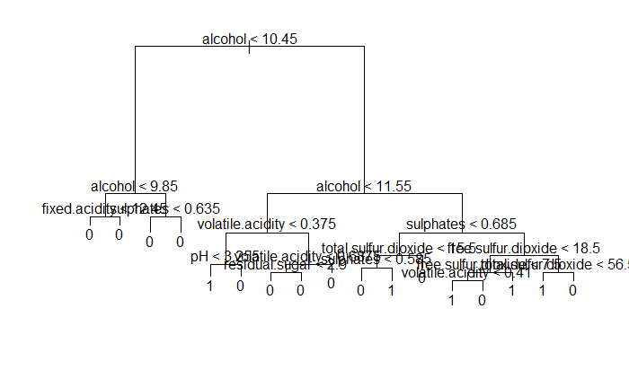

```r
plot(CART_post)
text(CART_post, pretty = 1)
```

```r
CART_prey <- predict(CART_post, newdata = wine_test, type = "class")
CART_cm <- table(wine_test$quality, CART_prey)
CART_cm
```

```
   CART_prey
      0   1
  0 432  16
  1  37  32
```

```r
CART_pr <- prediction(as.numeric(CART_prey), as.numeric(wine_test$quality))
auc <- performance(CART_pr, measure = "auc")
AUROC <- auc@y.values[[1]]
AUROC
```

```
[1] 0.7140269
```

```r
Perf_Table <- perf_eval(CART_cm)
Perf_Table
```

```
[1] 0.4637681 0.6666667 0.9642857 0.8974855 0.6687339 0.5470085
```

### titanic 데이터

#### 분류 성능 평가

전반적으로 wine데이터에 비하여 지표들이 비교적 좋은 성능을 보여준다. 그렇다고 매우 좋은 성능이라고는 보기힘들고, TN의 값이 0.9로 높아서 사망자를 예측하는데 좋은 성능을 보여줄 것이다.

[output not shown]

```r
titanic <- read.csv("train_titanic.csv", header=T, na.strings=c(""))
titanic <- titanic[,c(-1,-4,-9,-11)]
titanic$Age[is.na(titanic$Age)] <- mean(titanic$Age,na.rm=T)
titanic$Embarked[is.na(titanic$Embarked)] <- 'S'

#titanic$Sex <- ifelse(titanic$Sex == 'male', 1, 0)
titanic$Sex <- as.factor(titanic$Sex)
titanic$Embarked <- as.factor(titanic$Embarked)
titanic$Survived <- as.factor(titanic$Survived)

ratio <- 0.7
indexes_titanic <- sample(2, nrow(titanic), replace=TRUE, prob=c(ratio, 1-ratio))
titanic_train <- titanic[indexes_titanic==1,]
titanic_test <- titanic[indexes_titanic==2,]

CART_post_titanic <- tree(Survived ~ .,data = titanic_train)
summary(CART_post_titanic)
```

```
Classification tree:
tree(formula = Survived ~ ., data = titanic_train)
Variables actually used in tree construction:
[1] "Sex"    "Pclass" "Fare"   "Age"
Number of terminal nodes:  8
Residual mean deviance:  0.7968 = 479.7 / 602
Misclassification error rate: 0.1721 = 105 / 610
```

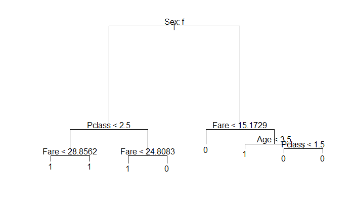

```r
plot(CART_post_titanic)
text(CART_post_titanic, pretty = 1)
```

```r
CART_prey_titanic <- predict(CART_post_titanic, newdata = titanic_test, type = "class")
CART_cm_titanic <- table(titanic_test$Survived, CART_prey_titanic)
CART_cm_titanic
```

```
   CART_prey_titanic
      0   1
  0 147  21
  1  39  74
```

```r
CART_pr_titanic <- prediction(as.numeric(CART_prey_titanic), as.numeric(titanic_test$Survived))
auc_titanic <- performance(CART_pr_titanic, measure = "auc")
AUROC_titanic <- auc_titanic@y.values[[1]]
AUROC_titanic
```

```
[1] 0.7649336
```

```r
Perf_Table_titanic <- perf_eval(CART_cm_titanic)
Perf_Table_titanic
```

```
[1] 0.6548673 0.7789474 0.8750000 0.7864769 0.7569735 0.7115385
```

## [Q3] 앞에서 생성한 Tree에 대해서 적절한 Post-Pruning을 수행한 뒤 결과물을 Plotting하고 이에 대한 해석을 수행하시오. Pruning 전과 후에 Split에 사용된 변수는 어떤 변화가 있는가? Test dataset에 대한 분류 성능을 평가하고 [Q2]의 결과와 비교해보시오.

### Wine 데이터

분류 성능에 있어서는 노드의 수를 많이 감소시켰음에도 불구하고, 분류 성능이 크게 감소하지 않았다. 프루닝을 함으로써 약간의 성능을 포기하고, cost 측면에서 이득을 보았음을 알 수 있다.

|  | TPR | PRE | TNR | ACC | BCR | F1 | AUROC |
| --- | --- | --- | --- | --- | --- | --- | --- |
| pruning 전 | 0.46 | 0.67 | 0.96 | 0.90 | 0.67 | 0.55 | 0.71 |
| pruning 후 | 0.46 | 0.62 | 0.96 | 0.89 | 0.67 | 0.53 | 0.71 |

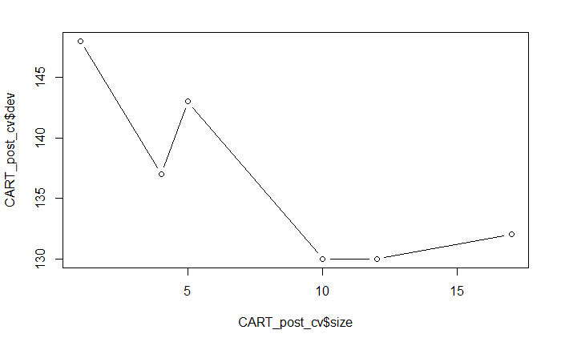

```r
CART_post_cv <- cv.tree(CART_post, FUN = prune.misclass)

plot(CART_post_cv$size, CART_post_cv$dev, type = "b")
```

```r
CART_post_cv
```

```
$size
[1] 17 12 10  5  4  1

$dev
[1] 132 130 130 143 137 148

$k
[1]     -Inf 0.000000 0.500000 5.000000 6.000000 9.666667

$method
[1] "misclass"

attr(,"class")
[1] "prune"         "tree.sequence"
```

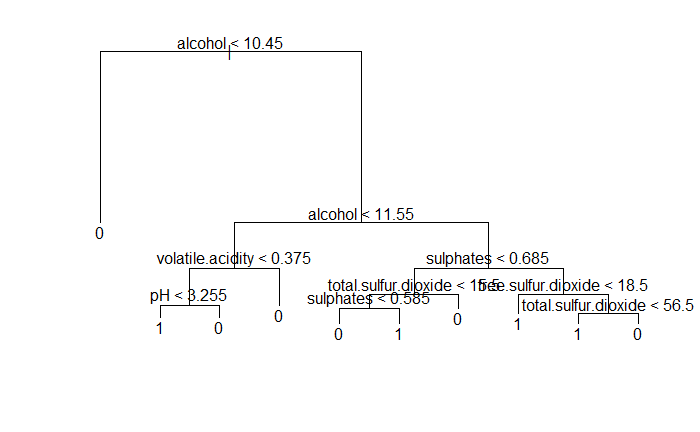

```r
CART_post_pruned <- prune.misclass(CART_post, best = 10)
plot(CART_post_pruned)
text(CART_post_pruned, pretty = 1)
```

```r
CART_post_prey <- predict(CART_post_pruned, wine_test, type = "class")
CART_post_cm <- table(wine_test$quality, CART_post_prey)
CART_post_cm
```

```
   CART_post_prey
      0   1
  0 428  20
  1  37  32
```

```r
CART_post_pr <- prediction(as.numeric(CART_post_prey), as.numeric(wine_test$quality))
auc_post <- performance(CART_post_pr, measure = "auc")
AUROC_post <- auc_post@y.values[[1]]
AUROC_post
```

```
[1] 0.7095626
```

```r
Perf_Table <- perf_eval(CART_post_cm)
Perf_Table
```

```
[1] 0.4637681 0.6153846 0.9553571 0.8897485 0.6656307 0.5289256
```

### titanic 데이터

[output not shown]

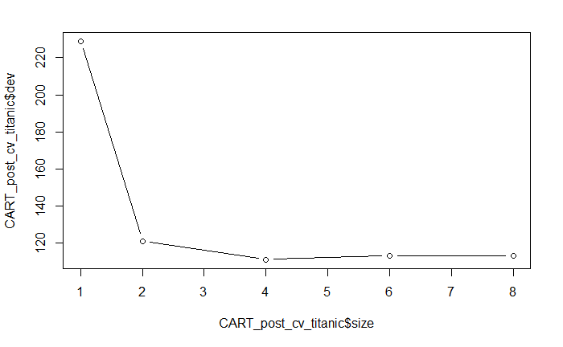

```r
CART_post_cv_titanic <- cv.tree(CART_post_titanic, FUN = prune.misclass)

plot(CART_post_cv_titanic$size, CART_post_cv_titanic$dev, type = "b")
```

```r
CART_post_cv_titanic
```

```
$size
[1] 8 6 4 2 1

$dev
[1] 113 113 111 121 229

$k
[1]  -Inf   0.0   2.5   5.5 108.0

$method
[1] "misclass"

attr(,"class")
[1] "prune"         "tree.sequence"
```

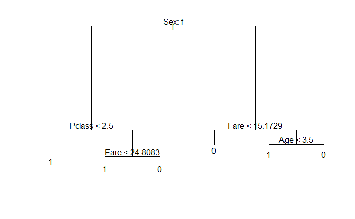

```r
CART_post_pruned_titanic <- prune.misclass(CART_post_titanic, best = 6)
plot(CART_post_pruned_titanic)
text(CART_post_pruned_titanic, pretty = 1)
```

```r
CART_post_prey_titanic <- predict(CART_post_pruned_titanic, titanic_test, type = "class")
CART_post_cm_titanic <- table(titanic_test$Survived, CART_post_prey_titanic)
CART_post_cm_titanic
```

```
   CART_post_prey_titanic
      0   1
  0 147  21
  1  39  74
```

```r
CART_post_pr_titanic <- prediction(as.numeric(CART_post_prey_titanic), as.numeric(titanic_test$Survived))
auc_post_titanic <- performance(CART_post_pr_titanic, measure = "auc")
AUROC_post_titanic <- auc_post_titanic@y.values[[1]]
AUROC_post_titanic
```

```
[1] 0.7649336
```

```r
Perf_Table_titanic <- perf_eval(CART_post_cm_titanic)
Perf_Table_titanic
```

```
[1] 0.6548673 0.7789474 0.8750000 0.7864769 0.7569735 0.7115385
```

## [Q3] “party” package를 사용하여 다음조건에 맞는 Pre-pruning을 수행하여 가장 최적의 min_criterion, min_split, max_depth 값 을 찾아보시오.

(조건 1) 각 하이퍼파라미터들은 최소 5 가지 이상의 후보값을 가질 것(총 125가지 이상)  
(조건 2) 평가지표는 Validation Dataset에 대한 AUROC 사용

### Wine 데이터

하이퍼 파라미터들의 후보는 다음과 같이 설정하였다.

min_criterion : 0.8, 0.85, 0.9, 0.95, 0.99  
min_split : 5, 10, 15, 20, 30  
max_dpeth : 1, 3, 5, 7, 9

Pre-pruning 수행 결과 최적 파라미터는 다음과 같다.  
AUROC = 0.89  
min_criterion :0.80  
min_split : 5  
max_depth : 3

```r
wine2 <- read.csv("winequality-red.csv")
wine2$quality <- ifelse(wine2$quality >= 6.5, 1, 0)
wine2$quality <- as.factor(wine2$quality)


ratio2 <- 0.6
indexes2 <- sample(3, nrow(wine2), replace=TRUE, prob=c(ratio2, (1-ratio2)/2,(1-ratio2)/2))
CART_trn <- wine2[indexes2==1,]
CART_val <- wine2[indexes2==2,]
CART_tst <- wine2[indexes2==3,]


# Construct single tree and evaluation
# tree parameter settings
min_criterion = c(0.8, 0.85, 0.9, 0.95, 0.99)
min_split = c(5, 10, 15, 20, 30)
max_depth = c(1, 3, 5, 7, 9)
CART_pre_search_result = matrix(0,length(min_criterion)*length(min_split)*length(max_depth),11)
colnames(CART_pre_search_result) <- c("min_criterion", "min_split", "max_depth",
                           "TPR", "Precision", "TNR", "ACC", "BCR", "F1", "AUROC", "N_leaves")

iter_cnt = 1

for (i in 1:length(min_criterion)){
  for ( j in 1:length(min_split)){
    for ( k in 1:length(max_depth)){

      cat("CART Min criterion:", min_criterion[i], ", Min split:", min_split[j], ", Max depth:", max_depth[k], "\n")
      tmp_control = ctree_control(mincriterion = min_criterion[i], minsplit = min_split[j], maxdepth = max_depth[k])
      tmp_tree <- ctree(quality ~ ., data = CART_trn, controls = tmp_control)
      tmp_tree_val_prediction <- predict(tmp_tree, newdata = CART_val)
      tmp_tree_val_response <- treeresponse(tmp_tree, newdata = CART_val)
      tmp_tree_val_prob <- 1-unlist(tmp_tree_val_response, use.names=F)[seq(1,nrow(CART_val)*2,2)]
      tmp_tree_val_rocr <- prediction(tmp_tree_val_prob, CART_val$quality)
      tmp_tree_val_cm <- table(CART_val$quality, tmp_tree_val_prediction)

      # parameters
      CART_pre_search_result[iter_cnt,1] = min_criterion[i]
      CART_pre_search_result[iter_cnt,2] = min_split[j]
      CART_pre_search_result[iter_cnt,3] = max_depth[k]
      # Performances from the confusion matrix
      CART_pre_search_result[iter_cnt,4:9] = perf_eval(tmp_tree_val_cm)
      # AUROC
      CART_pre_search_result[iter_cnt,10] = unlist(performance(tmp_tree_val_rocr, "auc")@y.values)
      # Number of leaf nodes
      CART_pre_search_result[iter_cnt,11] = length(nodes(tmp_tree, unique(where(tmp_tree))))
      iter_cnt = iter_cnt + 1
    }
  }
}

# Find the best set of parameters
CART_pre_search_result <- CART_pre_search_result[order(CART_pre_search_result[,10], decreasing = T),]
CART_pre_search_result
best_criterion <- CART_pre_search_result[1,1]
best_split <- CART_pre_search_result[1,2]
best_depth <- CART_pre_search_result[1,3]

tree_control = ctree_control(mincriterion = best_criterion, minsplit = best_split, maxdepth = best_depth)
```

[output not shown]

### Titanic 데이터

하이퍼 파라미터들의 후보는 다음과 같이 설정하였다.

min_criterion : 0.8, 0.85, 0.9, 0.95, 0.99  
min_split : 5, 10, 15, 20, 30  
max_dpeth : 1, 3, 5, 7, 9

```r
titanic2 <- read.csv("train_titanic.csv", header=T, na.strings=c(""))
titanic2_test <- read.csv("test_titanic.csv", header=T, na.strings=c(""))

titanic2 <- titanic2[,c(-1,-4,-9,-11)]
titanic2_test <- titanic2_test[,c(-1,-3,-8,-10)]

titanic2$Age[is.na(titanic2$Age)] <- mean(titanic2$Age,na.rm=T)
titanic2$Embarked[is.na(titanic2$Embarked)] <- 'S'
titanic2_test$Age[is.na(titanic2_test$Age)] <- mean(titanic2_test$Age,na.rm=T)
titanic2_test$Fare[is.na(titanic2_test$Fare)] <- mean(titanic2_test$Fare,na.rm=T)

titanic2$Sex <- as.factor(titanic2$Sex)
titanic2$Embarked <- as.factor(titanic2$Embarked)
titanic2$Survived <- as.factor(titanic2$Survived)

titanic2_test$Sex <- as.factor(titanic2_test$Sex)
titanic2_test$Embarked <- as.factor(titanic2_test$Embarked)

ratio <- 0.7
indexes <- sample(2, nrow(titanic2), replace=TRUE, prob=c(ratio, 1-ratio))
titanic2_train <- titanic2[indexes==1,]
titanic2_valid <- titanic2[indexes==2,]


# Construct single tree and evaluation
# tree parameter settings
min_criterion = c(0.8, 0.85, 0.9, 0.95, 0.99)
min_split = c(5, 10, 15, 20, 30)
max_depth = c(1, 3, 5, 7, 9)
CART_pre_search_result_titanic = matrix(0,length(min_criterion)*length(min_split)*length(max_depth),11)
colnames(CART_pre_search_result_titanic) <- c("min_criterion", "min_split", "max_depth",
                           "TPR", "Precision", "TNR", "ACC", "BCR", "F1", "AUROC", "N_leaves")

iter_cnt = 1

for (i in 1:length(min_criterion)){
  for ( j in 1:length(min_split)){
    for ( k in 1:length(max_depth)){

      cat("CART Min criterion:", min_criterion[i], ", Min split:", min_split[j], ", Max depth:", max_depth[k], "\n")
      tmp_control_titanic = ctree_control(mincriterion = min_criterion[i], minsplit = min_split[j], maxdepth = max_depth[k])
      tmp_tree_titanic <- ctree(Survived ~ ., data = titanic2_train, controls = tmp_control_titanic)
      tmp_tree_val_prediction_titanic <- predict(tmp_tree_titanic, newdata = titanic2_valid)
      tmp_tree_val_response_titanic <- treeresponse(tmp_tree_titanic, newdata = titanic2_valid)
      tmp_tree_val_prob_titanic <- 1-unlist(tmp_tree_val_response_titanic, use.names=F)[seq(1,nrow(titanic2_valid)*2,2)]
      tmp_tree_val_rocr_titanic <- prediction(tmp_tree_val_prob_titanic, titanic2_valid$Survived)
      tmp_tree_val_cm_titanic <- table(titanic2_valid$Survived, tmp_tree_val_prediction_titanic)

      # parameters
      CART_pre_search_result_titanic[iter_cnt,1] = min_criterion[i]
      CART_pre_search_result_titanic[iter_cnt,2] = min_split[j]
      CART_pre_search_result_titanic[iter_cnt,3] = max_depth[k]
      # Performances from the confusion matrix
      CART_pre_search_result_titanic[iter_cnt,4:9] = perf_eval(tmp_tree_val_cm_titanic)
      # AUROC
      CART_pre_search_result_titanic[iter_cnt,10] = unlist(performance(tmp_tree_val_rocr_titanic, "auc")@y.values)
      # Number of leaf nodes
      CART_pre_search_result_titanic[iter_cnt,11] = length(nodes(tmp_tree_titanic, unique(where(tmp_tree_titanic))))
      iter_cnt = iter_cnt + 1
    }
  }
}

# Find the best set of parameters
CART_pre_search_result_titanic <- CART_pre_search_result_titanic[order(CART_pre_search_result_titanic[,10], decreasing = T),]
CART_pre_search_result_titanic
best_criterion_titanic <- CART_pre_search_result_titanic[1,1]
best_split_titanic <- CART_pre_search_result_titanic[1,2]
best_depth_titanic <- CART_pre_search_result_titanic[1,3]

tree_control_titanic = ctree_control(mincriterion = best_criterion, minsplit = best_split, maxdepth = best_depth)
```

[output not shown]

## [Q4] 최적의 결정나무의 Plot을 그리고, 대표적인 세 가지 규칙에 대해서 설명해 보시오.

### Wine 데이터

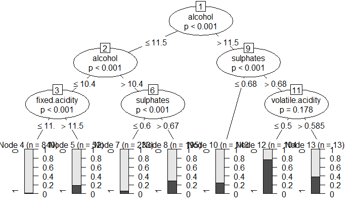

```r
CART_best <- ctree(quality ~ ., data = CART_trn, controls = tree_control)

plot(CART_best)
```

### Titanic 데이터

[figure not shown]

```r
CART_best_titanic <- ctree(Survived ~ ., data = titanic2_train, controls = tree_control_titanic)

plot(CART_best_titanic)
```

## [Q5] [Q4]에서 선택한 하이퍼라미터 조합을 이용하여 Training Dataset과 Validation Dataset을 결합한 데이터셋을 학습한뒤, Test Dataset에 적용해보고 분류성능을 평가하시오.

### Wine 데이터

TP, PRE, BCR, F1는 낮게 나오지만 TN, 정확도, AUROC은 상당히 높게 나온다. 좋은 와인을 분류하는데에는 별로 좋은 분류기가 아니지만, 나쁜 와인을 걸러내는데에는 좋은 분류기가 될 수 있다. 종합적으로 생각하면 좋은 모델이라고 볼 수 없지만, 나쁜 와인을 탐지하는 경우에는 사용할 수 있다. 정확도가 높다고 무조건 좋은 모델이라고 할 수 없다.

|  | TPR | PRE | TNR | ACC | BCR | F1 | AUROC |
| --- | --- | --- | --- | --- | --- | --- | --- |
| pre-pruning | 0.24 | 0.52 | 0.96 | 0.86 | 0.48 | 0.32 | 0.81 |

```r
CART_trn <- rbind(CART_trn, CART_val)

CART_pre <- ctree(quality ~ ., data = CART_trn, controls = tree_control)
CART_pre_prediction <- predict(CART_pre, newdata = CART_tst)
CART_pre_response <- treeresponse(CART_pre, newdata = CART_tst)

# Performance of the best tree
CART_pre_cm <- table(CART_tst$quality, CART_pre_prediction)
CART_pre_cm
```

```
   CART_pre_prediction
      0   1
  0 266  10
  1  35  11
```

```r
Perf_Table <- perf_eval(CART_pre_cm)
Perf_Table
```

```
[1] 0.2391304 0.5238095 0.9637681 0.8602484 0.4800690 0.3283582
```

```r
# Plot the ROC
CART_pre_prob <- 1-unlist(CART_pre_response, use.names=F)[seq(1,nrow(CART_tst)*2,2)]
CART_pre_rocr <- prediction(CART_pre_prob, CART_tst$quality)
CART_pre_perf <- performance(CART_pre_rocr, "auc")
AUROC_pre <- CART_pre_perf@y.values[[1]]
AUROC_pre
```

```
[1] 0.8050567
```

```r
#plot(CART_pre_perf, col=5, lwd = 3)

#plot(CART_pre)
#plot(CART_pre, type="simple")
```

### Titanic 데이터

타이타닉 데이터셋의 test셋에는 종속변수가 없다. 따라서 training 데이터로 학습한 트리를 test 데이터에 적용하여 예측값을 도출 하였다. test셋에 대한 분류성능은 평가할 수 없으므로 valid 데이터를 이용하여 분류성능을 평가하였다.

|  | TPR | PRE | TNR | ACC | BCR | F1 | AUROC |
| --- | --- | --- | --- | --- | --- | --- | --- |
| pre-pruning | 0.72 | 0.81 | 0.91 | 0.85 | 0.81 | 0.76 | 0.87 |

```r
titanic2_train <- rbind(titanic_train, titanic2_valid)

CART_pre_titanic <- ctree(Survived ~ ., data = titanic2_train, controls = tree_control_titanic)
CART_pre_prediction_titanic <- predict(CART_pre_titanic, newdata = titanic2_test)
CART_pre_response_titanic <- treeresponse(CART_pre_titanic, newdata = titanic2_test)

# valid 이용
CART_pre_prediction_titanic2 <- predict(CART_pre_titanic, newdata = titanic2_valid)
CART_pre_response_titanic2 <- treeresponse(CART_pre_titanic, newdata = titanic2_valid)

# Performance of the best tree
CART_pre_cm_titanic <- table(titanic2_valid$Survived, CART_pre_prediction_titanic2)
CART_pre_cm_titanic
```

```
   CART_pre_prediction_titanic2
      0   1
  0 167  16
  1  27  69
```

```r
Perf_Table_titanic2 <- perf_eval(CART_pre_cm_titanic)
Perf_Table_titanic2
```

```
[1] 0.7187500 0.8117647 0.9125683 0.8458781 0.8098818 0.7624309
```

```r
# Plot the ROC
CART_pre_prob_titanic <- 1-unlist(CART_pre_response_titanic2, use.names=F)[seq(1,nrow(titanic2_valid)*2,2)]
CART_pre_rocr_titanic <- prediction(CART_pre_prob_titanic, titanic2_valid$Survived)
CART_pre_perf_titanic <- performance(CART_pre_rocr_titanic, "auc")
AUROC_pre_titanic <- CART_pre_perf_titanic@y.values[[1]]
AUROC_pre_titanic
```

```
[1] 0.8689663
```

## [Q6] 과제 2를 수행하기위해 사용된 데이터셋(Dataset 1)과 이번 과제수행을 위해 선택된 데이터셋(Dataset 2)에 대해서 각각 로지스틱 회귀분석을 수행하여 Test Dataset에 대한 다음 Confusion Matrix를 채우고 이에 대한 결과를 해석해 보시오.

| Dataset | Model | TPR | TNR | ACC | BCR | F1-Measure |
| --- | --- | --- | --- | --- | --- | --- |
| Wine | Logistic Regression | 0.32 | 0.95 | 0.86 | 0.55 | 0.39 |
| pre-pruning | Decision Tree | 0.24 | 0.96 | 0.86 | 0.48 | 0.32 |
| Titanic | Logistic Regression | 0.72 | 0.85 | 0.80 | 0.78 | 0.73 |
| pre-pruning | Decision Tree | 0.72 | 0.91 | 0.85 | 0.81 | 0.76 |

데이터셋1에서 로지스틱 회귀분석을 수행한 결과 디시전트리와 비슷한 수행결과가 나타났다. TPR, BCR, F1은 0.32, 0.55, 0.39로 DT보다 높고, TNR, ACC는 거의 같다. 로지스틱 회귀분석의 결과가 디시전트리의 결과보다 조금 더 나은 성능을 보여준다고 할 수 있다. 반면, 전반적으로 데이터셋에 대해서 좋은 결과를 보여주는 모델이 아니다.

데이터셋2에서 로지스틱 회귀분석을 수행한 결과도 디시전트리의 결과가 거의 비슷하게 나왔다. TNR, ACC, BCR, F1 값이 디시전트리의 값 보다 낮게 나온다. 디시전 트리의 성능이 로지스틱 회귀분석보다 좋은 성능을 보다준다고 결론 지을 수 있다.

```r
perf_eval(cm_test_wine)
```

```
[1] 0.3188406 0.4888889 0.9486607 0.8646035 0.5499741 0.3859649
```

```r
perf_eval(cm_test_titanic)
```

```
[1] 0.7216495 0.7446809 0.8471338 0.7992126 0.7818783 0.7329843
```

## [Q7] 각 데이터셋 마다 Logistic Regression에 의해 중요하다고 판별된 변수들과 의사결정나무에 의해 중요하다고 판별된 변수들을 확인해 보고 차이가 있는지의 여부와, 차이가 존재할 경우 그 이유에 대한 본인의 생각을 서술해 보시오.

데이터셋1(와인)에서 중요한 변수는 로지스틱 리그레션에서 alcohol, sulphates, total.sulfur.dioxide이고, 디시전 트리에서는 alcohol, volatile acidity, fixed acidity, sulphates이다.

데이터셋2(타이타닉)에서 중요한 변수는 로지스틱 리그레션에서는 Pclass, Sex, Age, SibSp 변수이고, 디시전 트리에서는 Sex, Pclass, Age, Sibsp, Fare로 나타났다.

두 경우 모두 매우 영향이 높은 변수에 대해서는 공통적으로 중요하다고 판별되었다. 반면, 로지스틱 리그레션에서 중요도가 낮은 변수와, 디시전 트리에서 split point가 나중에 가까운 변수들에 대해서는 약간의 차이가 존재한다. 기하학적인 관점에서는 디시전 트리는 독립변수들의 축에 수직으로 경계를 나누고, 로지스틱 리그레션은 1차식의 모양으로 경계를 나누기 때문에 분류하는 측면에서 다른 결과가 나올 수 있다고 생각할 수 있다. 대수적인 관점에서 디시전 트리는 각 독립변수를 각각의 split point에서 계산한 값을 비교하여 분기점을 정한다. 각각의 변수에 대해서 독립적으로 계산이 진행된다. 반면, 로지스틱 리그레션은 독립변수 전체를 이용하여 계산이 이루어진다. 이러한 차이가 중요한 변수들의 차이를 가져온다.

```r
summary(model_wine)
```

```
Call:
glm(formula = quality ~ ., family = binomial(link = "logit"),
    data = wine_train)

Deviance Residuals:
    Min       1Q   Median       3Q      Max
-3.0051  -0.4133  -0.2024  -0.1149   2.9680

Coefficients:
                       Estimate Std. Error z value Pr(>|z|)
(Intercept)           3.059e+02  1.353e+02   2.261  0.02376 *
fixed.acidity         2.780e-01  1.590e-01   1.748  0.08043 .
volatile.acidity     -2.191e+00  9.331e-01  -2.349  0.01885 *
citric.acid           1.122e+00  1.051e+00   1.067  0.28580
residual.sugar        2.233e-01  9.448e-02   2.364  0.01810 *
chlorides            -9.176e+00  4.990e+00  -1.839  0.06591 .
free.sulfur.dioxide   3.852e-03  1.508e-02   0.255  0.79837
total.sulfur.dioxide -1.552e-02  5.864e-03  -2.647  0.00813 **
density              -3.221e+02  1.383e+02  -2.329  0.01984 *
pH                    3.430e-01  1.203e+00   0.285  0.77549
sulphates             3.657e+00  7.032e-01   5.201 1.99e-07 ***
alcohol               7.866e-01  1.608e-01   4.891 1.00e-06 ***
---
Signif. codes:  0 ‘***’ 0.001 ‘**’ 0.01 ‘*’ 0.05 ‘.’ 0.1 ‘ ’ 1

(Dispersion parameter for binomial family taken to be 1)

    Null deviance: 863.61  on 1081  degrees of freedom
Residual deviance: 575.46  on 1070  degrees of freedom
AIC: 599.46

Number of Fisher Scoring iterations: 6
```

```r
summary(model_wine)
```

[output not shown]

```r
summary(model_titanic)
```

[output not shown]